# Lecture 6-2

# Plotting Directly from a Pandas Data Frame

DataFrames in Pandas support basic visualizations directly.

https://pandas.pydata.org/pandas-docs/stable/reference/api/pandas.DataFrame.plot.html

### Example 1:

A data frame with several columns of time-series data

```python
df = pd.DataFrame(np.random.randn(1000, 4), index = ts.index, columns = list('ABCD'))
```

```python
df = df.cumsum()
df
```

|  | A | B | C | D |
| --- | --- | --- | --- | --- |
| 2000-01-01 | 1.228413 | -0.455540 | -0.532579 | -1.028464 |
| 2000-01-02 | 2.621425 | 0.000538 | -0.742925 | 1.427698 |
| 2000-01-03 | 2.170190 | -1.408664 | -1.085901 | 2.218128 |
| 2000-01-04 | 1.959056 | -1.738246 | -0.956508 | 2.225535 |
| 2000-01-05 | 1.871284 | -0.332684 | -0.550996 | 0.869890 |
| ... | ... | ... | ... | ... |
| 2002-09-22 | 8.019642 | -1.526915 | 51.653375 | -3.242759 |
| 2002-09-23 | 8.525085 | -2.704152 | 50.186367 | -2.390122 |
| 2002-09-24 | 8.122309 | -0.464831 | 50.595956 | -2.749689 |
| 2002-09-25 | 10.585510 | 0.196054 | 51.958605 | -1.728218 |
| 2002-09-26 | 11.858522 | 0.356034 | 49.999471 | -3.080693 |

1000 rows × 4 columns

Calling plot on the data frame will produce a plot with a line for each column with a legend

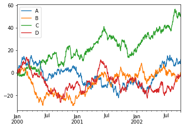

```python
plt.figure()
df.plot()
```

You can also call plot on a single series and specify kind = "bar" to create a bar plot

```python
df.iloc[5]
```

```
A    2.575327
B    1.572246
C   -2.606275
D    0.626440
Name: 2000-01-06 00:00:00, dtype: float64
```

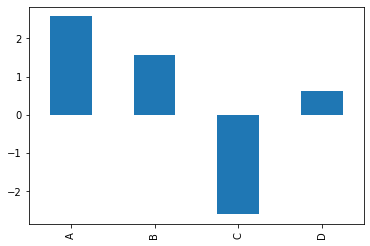

```python
df.iloc[5].plot(kind = "bar")
```

Here's a data frame with some random numbers.

```python
# These are random numbers and don't mean anything
df2 = pd.DataFrame(np.random.randint(0,10,size = (5, 4)), columns=['CA', 'NY', 'TX', 'OH'],
                   index = ["Tech","Agriculture","Manufacturing","Service","Other"])
df2
```

|  | CA | NY | TX | OH |
| --- | --- | --- | --- | --- |
| Tech | 8 | 2 | 0 | 2 |
| Agriculture | 6 | 0 | 1 | 0 |
| Manufacturing | 9 | 5 | 8 | 7 |
| Service | 6 | 8 | 3 | 3 |
| Other | 5 | 7 | 0 | 4 |

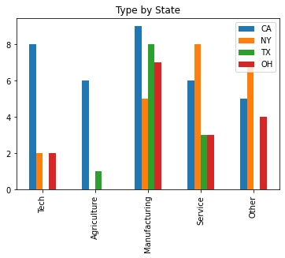

```python
df2.plot.bar()
plt.title("Type by State")
```

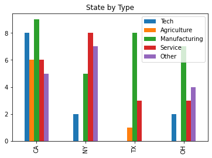

```python
df2.T.plot.bar()
plt.title("State by Type")
```

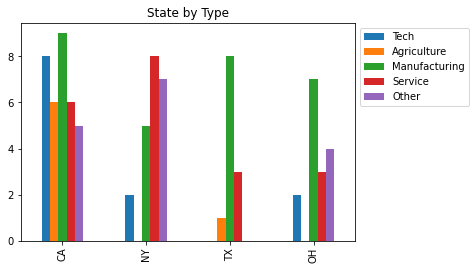

```python
df2.T.plot.bar()
plt.title("State by Type")
plt.legend(bbox_to_anchor=(1.0, 1.0), loc='upper left') # positions the legend outside the box
plt.show()
```

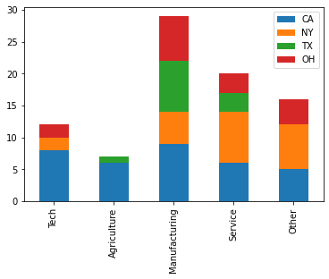

```python
df2.plot.bar(stacked=True)
```

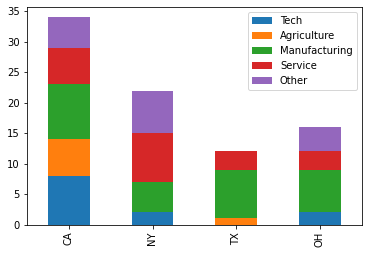

```python
df2.T.plot.bar(stacked=True)
```

A data frame consisting of random die rolls.

Column 'one' shows the sum after one roll. (min is 1, max is 6, dist is uniform)

Column 'two' shows the sum after two rolls. (min is 2, max is 12, dist is triangular)

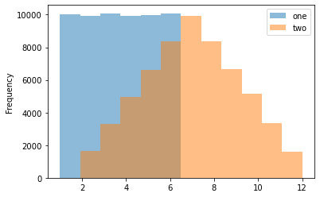

```python
df = pd.DataFrame(np.random.randint(1, 7, 60000), columns = ['one'])
df['two'] = df['one'] + np.random.randint(1, 7, 60000)
ax = df.plot.hist(bins=12, alpha=0.5)
```

Column 'three' shows the sum after three rolls. (min is 3, max is 18)

And so on... as we add more dice rolls, we see the central limit theorem start to take effect.

```python
df['three'] = df['two'] + np.random.randint(1, 7, 60000)
df['four'] = df['three'] + np.random.randint(1, 7, 60000)
df['five'] = df['four'] + np.random.randint(1, 7, 60000)
```

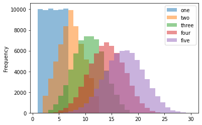

```python
df.plot.hist(bins = 30, alpha = 0.5)
```